# Over-representation Analysis

SAR: NA , Study: NA

Siying Huang (E0482362), Biomarker statistics team

created: 2023-06-01 , updated (2023-06-21)

# Over-representation Analysis

In this section, I will illustrate the principle of overpresentation analysis. There exist a variety of tools and methods for ORA. A few review papers for details:

- Huang, Sherman, and Lempicki (2009)

## Data prepartion

I will use the microarray data from smoking study as an example in this illustration. The details of this study is documented in this [paper](https://link.springer.com/article/10.1007/s00251-010-0431-6). The results (`rst` object) from differential gene expression analysis (DGEA) will be used here. Additionally, annotation file for gene IDs will be needed for R package based functions.

## Gene set selection

Normally these gene sets should represent major players in biological pathways. This can be achieved through the query from the biological databases or from other analytical approach such as co-expression analysis. For illustration purpose, here I randomly select 10 genes for gene set 1.

```r
set.seed(123)
gs1 <- sample(rst$ID, 10)
```

For gene set 2, I choose five most significantly differentially expressed genes, five genes not differentially expressed.

```r
gs2 <- c(head(rst$ID, 5), tail(rst$ID, 5))

print(glue::glue('geneset 1: {paste0(gs1, collapse = ", ")}
geneset 2: {paste0(gs2, collapse =", ")}'))
```

```
geneset 1: HAUS5, MYDGF, TRAPPC13, LINS1, SLC14A1, DYRK3, EIF3I, NRP2, 207479_at, SESN1
geneset 2: EBP, H3F3AP4, RAB2A, LOC100506248, MFSD11, NAP1L3, C19orf54, ADGRG6, PHF1, BCL2L14
```

### Define differentially expressed gene

Here I define differentially expressed genes with following criterion:

- adjusted p-value < 0.001
- log fold change > 5

These threshold criterion are not fixed can be varied depending on the context. Or it can be obtained from other analytical methods. The definition of these “over-represented” genes remains a controversial topic. However, it is out of the scope of this illustration.

```r
rst <- rst %>%
  mutate(
    de = adj.P.Val < 0.001 & abs(logFC) > 5,
    gs1 = ID %in% gs1,
    gs2 = ID %in% gs2,
  )
table(rst[, c("de", "gs1")])
```

```
       gs1
de      FALSE  TRUE
  FALSE 13735    10
  TRUE    318     0
```

```r
table(rst[, c("de", "gs2")])
```

```
       gs2
de      FALSE  TRUE
  FALSE 13740     5
  TRUE    313     5
```

## Over-representation analysis

> Over-representation analysis (ORA) is used to determine which a priori defined gene sets are more present (over-represented) in a subset of “interesting” genes than what would be expected by chance. – Huang, Sherman, and Lempicki (2009).

**The null hypothesis of ORA test:** being differentally expressed and belong to a particular pathway (gene set) are independent.

**Common statistical tests:** chi-square test, Fisher’s exact test. Note that when counts in a cell of a contigency table is small, chi-square approximation may not be accurate.

The following examples tests the hypothesis for the gene sets described above , e.g. if the genes in gene set 1 are differentially expressed between smokers and non-smokers.

**Gene set 1**

```r
conttab_gs1 <- as.table(table(rst[, c("gs1", "de")]))
print(conttab_gs1)
```

```
       de
gs1     FALSE  TRUE
  FALSE 13735   318
  TRUE     10     0
```

```r
chisq.test(conttab_gs1)
```

```
    Pearson's Chi-squared test with Yates' continuity correction

data:  conttab_gs1
X-squared = 2.3476e-24, df = 1, p-value = 1
```

```r
fisher.test(conttab_gs1, alternative = "greater")
```

```
    Fisher's Exact Test for Count Data

data:  conttab_gs1
p-value = 1
alternative hypothesis: true odds ratio is greater than 1
95 percent confidence interval:
   0 Inf
sample estimates:
odds ratio
         0
```

**Gene set 2**

```r
conttab_gs2 <- as.table(table(rst[, c("gs2", "de")]))
print(conttab_gs2)
```

```
       de
gs2     FALSE  TRUE
  FALSE 13740   313
  TRUE      5     5
```

```r
chisq.test(conttab_gs2)
```

```
    Pearson's Chi-squared test with Yates' continuity correction

data:  conttab_gs2
X-squared = 82.706, df = 1, p-value < 2.2e-16
```

```r
fisher.test(conttab_gs2, alternative = "greater")
```

```
    Fisher's Exact Test for Count Data

data:  conttab_gs2
p-value = 1.316e-06
alternative hypothesis: true odds ratio is greater than 1
95 percent confidence interval:
 12.47379      Inf
sample estimates:
odds ratio
  43.83007
```

## Over-respensentation analysis from R package

The advantage of performing ORA using R packages `clusterProfile` (which is the fusion of a few packages) is that the functions combine the step of database query and the step of testing in one go. The `clusterProfile` package currently provide biological database indicated in the *Over-representation analysis* box in the graph below.

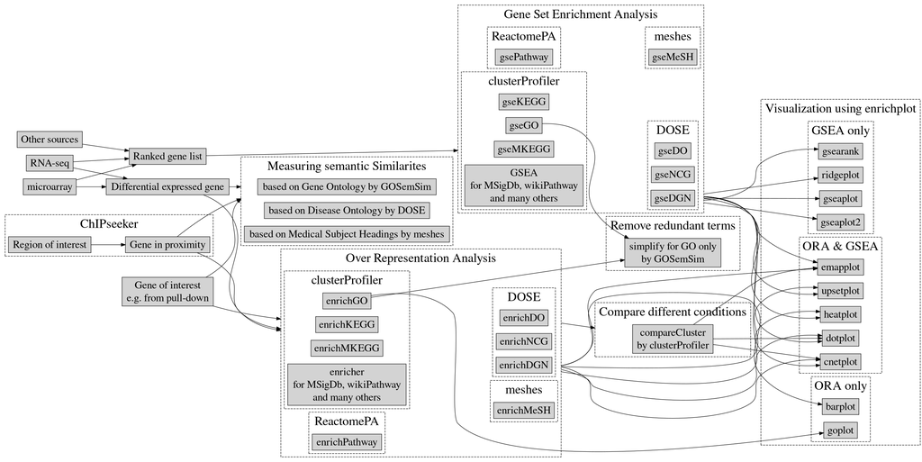

As shown in the graph, the ORA tests with different db queries are prefixed with `enrich`, such as `enrichGO`, `enrichDO`. Note that these functions are different than the test above. They first query the biological process databases and find the genes lie in the pathway(s). Then it will perform the test to see if the genes in the pathways are differentially expressed compared to the background genes. For example, I’m interested in the top 10 most significantly differentially expressed genes. I would like to query the biological pathways that these genes involve in then test if the gene in these pathways are significantly differentially expressed between smokers and non-smokers.

```r
gs3 <- head(rst$ID, 10)
gs3_ids <- gene_ids[which(gene_ids$hgnc_symbol %in% gs3), "entrezgene_id"] %>%
  as.character()
```

Gene IDs of geneset 3: 10682, 1316, 79157, 79684, 5862, 6651 **Note that not all gene symbols can be mapped to the gene IDs.**

## Test set up and result interpretations

To perform ORA in `clusterProfiler` one needs to provide following input.

**Setup parameters:**

- gene: a **character** vector of gene entrez ID in a gene set to be tested
- universe: a **character** vector of gene entrez ID in the background gene set. This background gene is defined by user. It could be all genes in the dataset or housekeeping genes or negative controls, depending on the purpose of comparison.
- ontology type: biological ontology type. This varies from different reference database. Check specific database for details.
- reference database: some function requires the input of database. one can either use the connection to online db or download to local, takes big storage space.

**Interpretation of results:**

|  | GO term | non-Go term |
| --- | --- | --- |
| enriched | 1 | 4 |
| background | 59 | 11535 |

```r
tab <- as.table(matrix(c(1, 59, 4, 11535), ncol = 2))
fisher.test(tab, alternative = "greater")
```

```
    Fisher's Exact Test for Count Data

data:  tab
p-value = 0.0256
alternative hypothesis: true odds ratio is greater than 1
95 percent confidence interval:
 1.983058      Inf
sample estimates:
odds ratio
  48.76889
```

## Examples

I list the example queries in the mostly used databases. If not specified, all the functions are from the `clusterProfile` package.

### GO

[Gene Ontology](http://geneontology.org/)

```r
rst_go <- enrichGO(gs3_ids,
  universe = as.character(gene_ids$entrezgene_id),
  OrgDb = org.Hs.eg.db,
  ont = "CC",
  pAdjustMethod = "BH",
  readable = F
)

str(rst_go, max.level = 2)
```

```
Formal class 'enrichResult' [package "DOSE"] with 14 slots
  ..@ result       :'data.frame':   10 obs. of  9 variables:
  ..@ pvalueCutoff : num 0.05
  ..@ pAdjustMethod: chr "BH"
  ..@ qvalueCutoff : num 0.2
  ..@ organism     : chr "Homo sapiens"
  ..@ ontology     : chr "CC"
  ..@ gene         : chr [1:6] "10682" "1316" "79157" "79684" ...
  ..@ keytype      : chr "ENTREZID"
  ..@ universe     : chr [1:11599] "2023" "2026" "2027" "1069" ...
  ..@ gene2Symbol  : chr(0)
  ..@ geneSets     :List of 62
  ..@ readable     : logi FALSE
  ..@ termsim      : num[0 , 0 ]
  ..@ method       : chr(0)
```

```r
datatable(rst_go@result,
  rownames = F,
  options = list(scrollX = "400px")
)
```

| ID | Description | GeneRatio | BgRatio | pvalue | p.adjust | qvalue | geneID | Count |
| --- | --- | --- | --- | --- | --- | --- | --- | --- |
| GO:0033116 | endoplasmic reticulum-Golgi intermediate compartment membrane | 1/5 | 60/11599 | 0.0256024637753363 | 0.0889159135161679 | 0.0467978492190357 | 5862 | 1 |
| GO:0042470 | melanosome | 1/5 | 100/11599 | 0.0423774357344833 | 0.0889159135161679 | 0.0467978492190357 | 5862 | 1 |
| GO:0048770 | pigment granule | 1/5 | 100/11599 | 0.0423774357344833 | 0.0889159135161679 | 0.0467978492190357 | 5862 | 1 |
| GO:0005793 | endoplasmic reticulum-Golgi intermediate compartment | 1/5 | 101/11599 | 0.042793829579281 | 0.0889159135161679 | 0.0467978492190357 | 5862 | 1 |
| GO:0001650 | fibrillar center | 1/5 | 105/11599 | 0.0444579567580839 | 0.0889159135161679 | 0.0467978492190357 | 1316 | 1 |
| GO:0005765 | lysosomal membrane | 1/5 | 275/11599 | 0.11307383697646 | 0.146250689823761 | 0.0769740472756636 | 5862 | 1 |
| GO:0098852 | lytic vacuole membrane | 1/5 | 275/11599 | 0.11307383697646 | 0.146250689823761 | 0.0769740472756636 | 5862 | 1 |
| GO:0005774 | vacuolar membrane | 1/5 | 310/11599 | 0.126698233760447 | 0.146250689823761 | 0.0769740472756636 | 5862 | 1 |
| GO:0016607 | nuclear speck | 1/5 | 337/11599 | 0.1370936482611 | 0.146250689823761 | 0.0769740472756636 | 6651 | 1 |
| GO:0005635 | nuclear envelope | 1/5 | 361/11599 | 0.146250689823761 | 0.146250689823761 | 0.0769740472756636 | 10682 | 1 |

```r
rst_go@geneSets["GO:0033116"]
```

```
$`GO:0033116`
 [1] "374"    "537"    "811"    "966"    "1075"   "1294"   "1453"   "1522"   "1604"   "2055"
[11] "2153"   "2157"   "2348"   "2801"   "2890"   "3630"   "3998"   "5265"   "5862"   "6091"
[21] "6811"   "6890"   "6891"   "6892"   "7039"   "8613"   "9321"   "9554"   "9570"   "9780"
[31] "10134"  "10175"  "10282"  "10652"  "10897"  "10945"  "10959"  "10960"  "10972"  "11018"
[41] "23423"  "24141"  "50999"  "51006"  "51226"  "51290"  "51614"  "53345"  "54732"  "55014"
[51] "64689"  "65258"  "79056"  "79058"  "79748"  "81501"  "81876"  "90411"  "90522"  "149111"
```

### KEGG

[Kyoto Encyclopedia of Genes and Genomes](https://www.genome.jp/kegg/) **Note**

I ran into bug from the older version of `clusterProfiler`. In order to get this function work, update R version and upgrade `DOSE` package if you use online reference. Alternatively download KEGG reference and set `use_internal_data = TRUE`. I can’t upgrade R in my local enviroment and don’t have space to download massive data. So I won’t be able to illustrate KEGG here.

```r
rst_kegg <- enrichKEGG(gs3_ids,
  universe = as.character(gene_ids$entrezgene_id),
  minGSSize = 1,
  pvalueCutoff = 0.3,
  organism = "hsa",
  use_internal_data = F
)
```

```
Error in download.KEGG.Path(species): 'species' should be one of organisms listed in 'http://www.genome.jp/kegg/catalog/org_list.html'...
```

KEGG module

```r
rst_mkegg <- enrichMKEGG(gs3_ids,
  universe = as.character(gene_ids$entrezgene_id),
  organism = "hsa",
  keyType = 'ncbi-geneid'
)
```

```
Error in download.KEGG.Module(species): 'species' should be one of organisms listed in 'http://www.genome.jp/kegg/catalog/org_list.html'...
```

```r
str(rst_mkegg, max.levels = 1)
```

```
Error in str(rst_mkegg, max.levels = 1): object 'rst_mkegg' not found
```

```r
datatable(rst_mkegg@result,
  rownames = F,
  options = list(scrollX = "400px")
)
```

```
Error in crosstalk::is.SharedData(data): object 'rst_mkegg' not found
```

### WikiPathways

[WikiPathways](https://www.wikipathways.org/)

```r
enrichWP(gs3_ids,
  organism = "Homo sapiens",
  universe = as.character(gene_ids$entrezgene_id)
)
```

```
Error in file(con, "r"): cannot open the connection to 'http://data.wikipathways.org/current/gmt/'
```

### Reactome

[Reactome](https://reactome.org/)

```r
rst_react <- ReactomePA::enrichPathway(gs3_ids,
  universe = as.character(gene_ids$entrezgene_id),
  qvalueCutoff = 0.1
)

str(rst_react, max.level = 2)
```

```
Formal class 'enrichResult' [package "DOSE"] with 14 slots
  ..@ result       :'data.frame':   7 obs. of  9 variables:
  ..@ pvalueCutoff : num 0.05
  ..@ pAdjustMethod: chr "BH"
  ..@ qvalueCutoff : num 0.1
  ..@ organism     : chr "human"
  ..@ ontology     : chr "Reactome"
  ..@ gene         : chr [1:6] "10682" "1316" "79157" "79684" ...
  ..@ keytype      : chr "ENTREZID"
  ..@ universe     : chr [1:7934] "10019" "10112" "10125" "1017" ...
  ..@ gene2Symbol  : chr(0)
  ..@ geneSets     :List of 14
  ..@ readable     : logi FALSE
  ..@ termsim      : num[0 , 0 ]
  ..@ method       : chr(0)
```

```r
datatable(rst_react@result,
  rownames = F,
  options = list(scrollX = "400px")
)
```

| ID | Description | GeneRatio | BgRatio | pvalue | p.adjust | qvalue | geneID | Count |
| --- | --- | --- | --- | --- | --- | --- | --- | --- |
| R-HSA-162658 | Golgi Cisternae Pericentriolar Stack Reorganization | 1/2 | 14/7934 | 0.00352622357695664 | 0.0185044993819718 | 0.00556526297202159 | 5862 | 1 |
| R-HSA-191273 | Cholesterol biosynthesis | 1/2 | 21/7934 | 0.00528699982342051 | 0.0185044993819718 | 0.00556526297202159 | 10682 | 1 |
| R-HSA-8873719 | RAB geranylgeranylation | 1/2 | 45/7934 | 0.0113121262517115 | 0.0263949612539935 | 0.00793833421172738 | 5862 | 1 |
| R-HSA-68875 | Mitotic Prophase | 1/2 | 74/7934 | 0.0185680674336759 | 0.0324941180089328 | 0.00977266707035573 | 5862 | 1 |
| R-HSA-8957322 | Metabolism of steroids | 1/2 | 133/7934 | 0.0332476639575121 | 0.0465467295405169 | 0.013999016403163 | 10682 | 1 |
| R-HSA-68886 | M Phase | 1/2 | 306/7934 | 0.0756535442358491 | 0.0882624682751573 | 0.0265451032406488 | 5862 | 1 |
| R-HSA-69278 | Cell Cycle, Mitotic | 1/2 | 439/7934 | 0.107607985214971 | 0.107607985214971 | 0.0323633038240513 | 5862 | 1 |

### DO

[Disease Ontology](https://disease-ontology.org/)

```r
DOSE::enrichDO(gs3_ids,
  universe = as.character(gene_ids$entrezgene_id)
)
```

```
#
# over-representation test
#
#...@organism    Homo sapiens
#...@ontology    DO
#...@keytype     ENTREZID
#...@gene    chr [1:6] "10682" "1316" "79157" "79684" "5862" "6651"
#...pvalues adjusted by 'BH' with cutoff <0.05
#...0 enriched terms found
#...Citation
  Guangchuang Yu, Li-Gen Wang, Guang-Rong Yan, Qing-Yu He. DOSE: an
  R/Bioconductor package for Disease Ontology Semantic and Enrichment
  analysis. Bioinformatics 2015, 31(4):608-609
```

### DisGeNET

[DisGeNET](https://www.disgenet.org/)

```r
rst_dgn <- DOSE::enrichDGN(gs3_ids,
  universe = as.character(gene_ids$entrezgene_id),
  readable = F
)
str(rst_dgn, max.level = 2)
```

```
Formal class 'enrichResult' [package "DOSE"] with 14 slots
  ..@ result       :'data.frame':   315 obs. of  9 variables:
  ..@ pvalueCutoff : num 0.05
  ..@ pAdjustMethod: chr "BH"
  ..@ qvalueCutoff : num 0.2
  ..@ organism     : chr "Homo sapiens"
  ..@ ontology     : chr "DisGeNET"
  ..@ gene         : chr [1:6] "10682" "1316" "79157" "79684" ...
  ..@ keytype      : chr "ENTREZID"
  ..@ universe     : chr [1:11429] "1468" "4210" "54808" "72" ...
  ..@ gene2Symbol  : chr(0)
  ..@ geneSets     :List of 536
  ..@ readable     : logi FALSE
  ..@ termsim      : num[0 , 0 ]
  ..@ method       : chr(0)
```

```r
datatable(rst_dgn@result,
  rownames = F,
  options = list(scrollX = "400px")
)
```

| ID | Description | GeneRatio | BgRatio | pvalue | p.adjust | qvalue | geneID | Count |
| --- | --- | --- | --- | --- | --- | --- | --- | --- |
| C0265677 | Congenital hemivertebra | 2/5 | 41/11429 | 0.000124709113169273 | 0.039283370648321 | 0.0196909126056747 | 10682/6651 | 2 |
| C0262444 | Abnormality of the dentition | 2/5 | 111/11429 | 0.000917131405450479 | 0.067375682817799 | 0.0337722720891223 | 10682/6651 | 2 |
| C0008445 | Chondrodysplasia Punctata | 1/5 | 10/11429 | 0.00436795005518886 | 0.067375682817799 | 0.0337722720891223 | 10682 | 1 |
| C0398593 | Specific granule deficiency | 1/5 | 10/11429 | 0.00436795005518886 | 0.067375682817799 | 0.0337722720891223 | 10682 | 1 |
| C4023808 | Hyperextensibility at elbow | 1/5 | 10/11429 | 0.00436795005518886 | 0.067375682817799 | 0.0337722720891223 | 6651 | 1 |
| C0022821 | Kyphosis deformity of spine | 2/5 | 253/11429 | 0.00467043424696425 | 0.067375682817799 | 0.0337722720891223 | 10682/6651 | 2 |
| C0158779 | Cervical rib | 1/5 | 11/11429 | 0.00480390418862653 | 0.067375682817799 | 0.0337722720891223 | 6651 | 1 |
| C0233762 | Hallucinations, Auditory | 1/5 | 11/11429 | 0.00480390418862653 | 0.067375682817799 | 0.0337722720891223 | 6651 | 1 |
| C0393735 | Headache Disorders | 1/5 | 11/11429 | 0.00480390418862653 | 0.067375682817799 | 0.0337722720891223 | 1316 | 1 |
| C0522216 | Abnormal auditory evoked potential | 1/5 | 11/11429 | 0.00480390418862653 | 0.067375682817799 | 0.0337722720891223 | 10682 | 1 |

[output cut: 305 more lines]

### MeSH

[MeSH](https://www.ncbi.nlm.nih.gov/mesh/)

The enrichement test function requires the feed the reference argument. One can either download the whole reference or connect on online db. The following code will create a local database in the cache directory. The location of the local cache can be found (and updated) with `getAnnotationHubCache` and `setAnnotationHubCache`; `removeCache` removes all cache resources.

```r
annot <- AnnotationHub::AnnotationHub(localHub = F)
print(annot)
# query annotation hub for MeSH database
hsa <- AnnotationHub::query(annot, c("MeSHDb", "Homo sapiens"))
print(str(hsa))
# download rosources to local cache directory
ref_hsa <- hsa[[1]]
MeSHDB <- MeSHDbi::MeSHDb(ref_hsa)
```

Otherwise one can install `MeSH.Hsa.eg.db` package in the local environment.

```r
# require installation of `MeSH.Hsa.eg.db` package.
# replace `MeSHDb = MeSHDB` if using local reference database.
rst_mesh <- meshes::enrichMeSH(gs3_ids,
  MeSHDb = "MeSH.Hsa.eg.db"
)
str(rst_mesh, max.level = 2)
```

```
Formal class 'enrichResult' [package "DOSE"] with 14 slots
  ..@ result       :'data.frame':   31 obs. of  9 variables:
  ..@ pvalueCutoff : num 0.05
  ..@ pAdjustMethod: chr "BH"
  ..@ qvalueCutoff : num 0.2
  ..@ organism     : chr "Human"
  ..@ ontology     : chr "MeSH"
  ..@ gene         : chr [1:6] "10682" "1316" "79157" "79684" ...
  ..@ keytype      : chr "UNKNOWN"
  ..@ universe     : chr [1:16528] "11093" "4867" "5068" "6868" ...
  ..@ gene2Symbol  : chr(0)
  ..@ geneSets     :List of 74
  ..@ readable     : logi FALSE
  ..@ termsim      : num[0 , 0 ]
  ..@ method       : chr(0)
```

```r
datatable(rst_mesh@result,
  rownames = F,
  options = list(scrollX = "400px")
)
```

| ID | Description | GeneRatio | BgRatio | pvalue | p.adjust | qvalue | geneID | Count |
| --- | --- | --- | --- | --- | --- | --- | --- | --- |
| D009385 | Neoplastic Processes | 1/4 | 11/16528 | 0.00265973377569595 | 0.0399584642320842 | 0.012211415215238 | 1316 | 1 |
| D016114 | Ichthyosis, X-Linked | 1/4 | 11/16528 | 0.00265973377569595 | 0.0399584642320842 | 0.012211415215238 | 10682 | 1 |
| D003873 | Dermatitis, Exfoliative | 1/4 | 16/16528 | 0.00386694815149202 | 0.0399584642320842 | 0.012211415215238 | 10682 | 1 |
| D002806 | Chondrodysplasia Punctata | 1/4 | 24/16528 | 0.00579621118401952 | 0.0419107050014516 | 0.0128080252975574 | 10682 | 1 |
| D004387 | Dupuytren Contracture | 1/4 | 28/16528 | 0.00675979112926639 | 0.0419107050014516 | 0.0128080252975574 | 1316 | 1 |
| D017496 | Hypopigmentation | 1/4 | 35/16528 | 0.00844437043272395 | 0.0436292472357404 | 0.013333216472722 | 10682 | 1 |
| D018901 | Peroxisomal Disorders | 1/4 | 43/16528 | 0.0103669790286649 | 0.0459109071269446 | 0.0140304979335314 | 10682 | 1 |
| D007640 |  | 1/4 | 50/16528 | 0.012046966810327 | 0.0466819963900172 | 0.0142661449069662 | 1316 | 1 |
| D045169 | Severe Acute Respiratory Syndrome | 1/4 | 61/16528 | 0.0146826249354489 | 0.0499658991062791 | 0.0152697144976744 | 1316 | 1 |
| D008052 | Lipid Metabolism, Inborn Errors | 1/4 | 67/16528 | 0.0161180319697675 | 0.0499658991062791 | 0.0152697144976744 | 10682 | 1 |

[output cut: 21 more lines]

```r
# library(RDAVIDWebService)
# enrichDAVID(gs3_ids,
# universe = as.character(gene_ids$entrezgene_id)
# )
```

## Pros and Cons of ORA

- Simple and straitforward
- can be used for exploratory analysis when there’s no prior hypothesis about any biological mechanism.
- However, can not infer the directly of differentially expressed pathway e.g. up-regulated or down-regulated. This is not so helpful when particularly interested in the pathways that a drug modulates.
- assumes the genes in the test are iid.

## Reference

Huang, Da Wei, Brad T. Sherman, and Richard A. Lempicki. 2009. “Bioinformatics Enrichment Tools: Paths Toward the Comprehensive Functional Analysis of Large Gene Lists.” *Nucleic Acids Research* 37 (1): 1–13. https://doi.org/10.1093/nar/gkn923.